# Module 11 Exercise (Analysis #3)

Morgan Taylor

11/5/2021

# Module 11: Machine Learning Models 1

This RMD corresponds to the assignment in [Module 11 for MADA 2021](https://andreashandel.github.io/MADAcourse/Assessment_ML_Models_1.html). It loads the processed data and fits a three machine learning models after some data pre-processing.

## Libraries required:

- here: for data loading/saving
- tidyverse: for data management
- tidymodels: for data modeling
- skimr: for variable summaries
- broom.mixed: for converting bayesian models to tidy tibbles
- rpart.plot: for visualizing a decision tree
- vip: for variable importance plots
- glmnet: for lasso models
- doParallel: for parallel backend for tuning processes
- ranger: for random forest models

## Load Data

Load the processed data from the `processed_data` folder in the project file.

```r
#path to data
#note the use of the here() package and not absolute paths
data_location <- here::here("data","processed_data","processeddata.rds")

#load data.
data <- readRDS(data_location)

#summary of data using skimr package
skimr::skim(data)
```

Data summary

| Name | data |
| --- | --- |
| Number of rows | 730 |
| Number of columns | 32 |
| _______________________ |  |
| Column type frequency: |  |
| factor | 31 |
| numeric | 1 |
| ________________________ |  |
| Group variables | None |

**Variable type: factor**

| skim_variable | n_missing | complete_rate | ordered | n_unique | top_counts |
| --- | --- | --- | --- | --- | --- |
| SwollenLymphNodes | 0 | 1 | FALSE | 2 | No: 418, Yes: 312 |
| ChestCongestion | 0 | 1 | FALSE | 2 | Yes: 407, No: 323 |
| ChillsSweats | 0 | 1 | FALSE | 2 | Yes: 600, No: 130 |
| NasalCongestion | 0 | 1 | FALSE | 2 | Yes: 563, No: 167 |
| CoughYN | 0 | 1 | FALSE | 2 | Yes: 655, No: 75 |
| Sneeze | 0 | 1 | FALSE | 2 | Yes: 391, No: 339 |
| Fatigue | 0 | 1 | FALSE | 2 | Yes: 666, No: 64 |
| SubjectiveFever | 0 | 1 | FALSE | 2 | Yes: 500, No: 230 |
| Headache | 0 | 1 | FALSE | 2 | Yes: 615, No: 115 |
| Weakness | 0 | 1 | FALSE | 4 | Mod: 338, Mil: 223, Sev: 120, Non: 49 |
| WeaknessYN | 0 | 1 | FALSE | 2 | Yes: 681, No: 49 |
| CoughIntensity | 0 | 1 | FALSE | 4 | Mod: 357, Sev: 172, Mil: 154, Non: 47 |
| CoughYN2 | 0 | 1 | FALSE | 2 | Yes: 683, No: 47 |
| Myalgia | 0 | 1 | FALSE | 4 | Mod: 325, Mil: 213, Sev: 113, Non: 79 |
| MyalgiaYN | 0 | 1 | FALSE | 2 | Yes: 651, No: 79 |
| RunnyNose | 0 | 1 | FALSE | 2 | Yes: 519, No: 211 |
| AbPain | 0 | 1 | FALSE | 2 | No: 639, Yes: 91 |
| ChestPain | 0 | 1 | FALSE | 2 | No: 497, Yes: 233 |
| Diarrhea | 0 | 1 | FALSE | 2 | No: 631, Yes: 99 |
| EyePn | 0 | 1 | FALSE | 2 | No: 617, Yes: 113 |
| Insomnia | 0 | 1 | FALSE | 2 | Yes: 415, No: 315 |
| ItchyEye | 0 | 1 | FALSE | 2 | No: 551, Yes: 179 |
| Nausea | 0 | 1 | FALSE | 2 | No: 475, Yes: 255 |
| EarPn | 0 | 1 | FALSE | 2 | No: 568, Yes: 162 |
| Hearing | 0 | 1 | FALSE | 2 | No: 700, Yes: 30 |
| Pharyngitis | 0 | 1 | FALSE | 2 | Yes: 611, No: 119 |
| Breathless | 0 | 1 | FALSE | 2 | No: 436, Yes: 294 |
| ToothPn | 0 | 1 | FALSE | 2 | No: 565, Yes: 165 |
| Vision | 0 | 1 | FALSE | 2 | No: 711, Yes: 19 |
| Vomit | 0 | 1 | FALSE | 2 | No: 652, Yes: 78 |
| Wheeze | 0 | 1 | FALSE | 2 | No: 510, Yes: 220 |

**Variable type: numeric**

| skim_variable | n_missing | complete_rate | mean | sd | p0 | p25 | p50 | p75 | p100 | hist |
| --- | --- | --- | --- | --- | --- | --- | --- | --- | --- | --- |
| BodyTemp | 0 | 1 | 98.94 | 1.2 | 97.2 | 98.2 | 98.5 | 99.3 | 103.1 | ▇▇▂▁▁ |

## Pre-processing

There are two steps in this pre-processing: (1) feature removal and (2) addressing low (“near-zero”) variance predictors.

**Feature Variable Removal** In the output above, there are three variables that have both a severity score and a yes/no feature: weakness, cough, and myalgia. There are actually two variables for cough yes/no. These variables are strongly correlated and therefore affect model performance. Solution: remove all yes/no versions of variables for which a severity score exists.

```r
#variable names to remove: WeaknessYN, MyalgiaYN, CoughYN, CoughYN2
featadj_data <- dplyr::select(data, -c(WeaknessYN, MyalgiaYN, CoughYN, CoughYN2))
```

These severity scores are also ordered, so we need to specify the order: None < Mild < Moderate < Severe.

```r
#myalgia
featadj_data$Myalgia <- ordered(featadj_data$Myalgia, labels = c("None", "Mild", "Moderate", "Severe"))

#weakness
featadj_data$Weakness <- ordered(featadj_data$Weakness, labels = c("None", "Mild", "Moderate", "Severe"))

#cough
featadj_data$CoughIntensity <- ordered(featadj_data$CoughIntensity, labels = c("None", "Mild", "Moderate", "Severe"))

#double check to confirm code worked
skimr::skim(featadj_data)
```

Data summary

| Name | featadj_data |
| --- | --- |
| Number of rows | 730 |
| Number of columns | 28 |
| _______________________ |  |
| Column type frequency: |  |
| factor | 27 |
| numeric | 1 |
| ________________________ |  |
| Group variables | None |

**Variable type: factor**

| skim_variable | n_missing | complete_rate | ordered | n_unique | top_counts |
| --- | --- | --- | --- | --- | --- |
| SwollenLymphNodes | 0 | 1 | FALSE | 2 | No: 418, Yes: 312 |
| ChestCongestion | 0 | 1 | FALSE | 2 | Yes: 407, No: 323 |
| ChillsSweats | 0 | 1 | FALSE | 2 | Yes: 600, No: 130 |
| NasalCongestion | 0 | 1 | FALSE | 2 | Yes: 563, No: 167 |
| Sneeze | 0 | 1 | FALSE | 2 | Yes: 391, No: 339 |
| Fatigue | 0 | 1 | FALSE | 2 | Yes: 666, No: 64 |
| SubjectiveFever | 0 | 1 | FALSE | 2 | Yes: 500, No: 230 |
| Headache | 0 | 1 | FALSE | 2 | Yes: 615, No: 115 |
| Weakness | 0 | 1 | TRUE | 4 | Mod: 338, Mil: 223, Sev: 120, Non: 49 |
| CoughIntensity | 0 | 1 | TRUE | 4 | Mod: 357, Sev: 172, Mil: 154, Non: 47 |
| Myalgia | 0 | 1 | TRUE | 4 | Mod: 325, Mil: 213, Sev: 113, Non: 79 |
| RunnyNose | 0 | 1 | FALSE | 2 | Yes: 519, No: 211 |
| AbPain | 0 | 1 | FALSE | 2 | No: 639, Yes: 91 |
| ChestPain | 0 | 1 | FALSE | 2 | No: 497, Yes: 233 |
| Diarrhea | 0 | 1 | FALSE | 2 | No: 631, Yes: 99 |
| EyePn | 0 | 1 | FALSE | 2 | No: 617, Yes: 113 |
| Insomnia | 0 | 1 | FALSE | 2 | Yes: 415, No: 315 |
| ItchyEye | 0 | 1 | FALSE | 2 | No: 551, Yes: 179 |
| Nausea | 0 | 1 | FALSE | 2 | No: 475, Yes: 255 |
| EarPn | 0 | 1 | FALSE | 2 | No: 568, Yes: 162 |
| Hearing | 0 | 1 | FALSE | 2 | No: 700, Yes: 30 |
| Pharyngitis | 0 | 1 | FALSE | 2 | Yes: 611, No: 119 |
| Breathless | 0 | 1 | FALSE | 2 | No: 436, Yes: 294 |
| ToothPn | 0 | 1 | FALSE | 2 | No: 565, Yes: 165 |
| Vision | 0 | 1 | FALSE | 2 | No: 711, Yes: 19 |
| Vomit | 0 | 1 | FALSE | 2 | No: 652, Yes: 78 |
| Wheeze | 0 | 1 | FALSE | 2 | No: 510, Yes: 220 |

**Variable type: numeric**

| skim_variable | n_missing | complete_rate | mean | sd | p0 | p25 | p50 | p75 | p100 | hist |
| --- | --- | --- | --- | --- | --- | --- | --- | --- | --- | --- |
| BodyTemp | 0 | 1 | 98.94 | 1.2 | 97.2 | 98.2 | 98.5 | 99.3 | 103.1 | ▇▇▂▁▁ |

**Low (“near-zero”) variance predictors** The skimr output shows there are some predictors that are fairly unbalanced with most patients reporting `no` and only a few `yes`. This can be handled automatically in `tidymodels` with `step_nzv()`, but it can be better to do it manually to ensure scientific relevance. Here, we will remove binary predictors that have <50 entries in one category. According to the `skimr::skim` output, there are two: `Hearing` and `Vision`.

```r
#drop Hearing and Vision from the dataset to create processed dataset for ML analysis
ML_processed <- dplyr::select(featadj_data, -c(Hearing, Vision))
```

## Analysis Code

Eventually we will rearrange the analysis files and scripts, but for the purposes of documentation, this is the analysis code for this exercise.

Here, we are focusing on a single outcome: BodyTemp (continuous). Therefore, these will be regression models, so we can compare using RMSE.

**Data Setup** Following the parameters determined in the assignment guidelines: * Set the random seed to `123` * Split the dataset into 70% training, 30% testing with `BodyTemp` as stratification * 5-fold cross validation, 5 times repeated, stratified on `BodyTemp` for the CV folds * Create a recipe for data and fitting that codes categorical variables as dummy variables

```r
#set random seed to 123
set.seed(123)

#split dataset into 70% training, 30% testing
#use BodyTemp as stratification
data_split <- rsample::initial_split(ML_processed, prop = 7/10,
                                     strata = BodyTemp)

#create dataframes for the two sets:
train_data <- rsample::training(data_split)
test_data <- rsample::testing(data_split)

#training set proportions by BodyTemp
train_data %>%
  dplyr::count(BodyTemp) %>%
  dplyr::mutate(prop = n / sum(n))
```

```
##    BodyTemp  n        prop
## 1      97.3  1 0.001968504
## 2      97.4  5 0.009842520
## 3      97.5  8 0.015748031
## 4      97.6  5 0.009842520
## 5      97.7 12 0.023622047
## 6      97.8 19 0.037401575
## 7      97.9 23 0.045275591
## 8      98.0 18 0.035433071
## 9      98.1 29 0.057086614
## 10     98.2 32 0.062992126
## 11     98.3 42 0.082677165
## 12     98.4 29 0.057086614
## 13     98.5 37 0.072834646
## 14     98.6 14 0.027559055
```

[output cut: 41 more lines]

```r
#testing set proportions by BodyTemp
test_data %>%
  dplyr::count(BodyTemp) %>%
  dplyr::mutate(prop = n / sum(n))
```

```
##    BodyTemp  n        prop
## 1      97.2  2 0.009009009
## 2      97.4  2 0.009009009
## 3      97.5  1 0.004504505
## 4      97.6  2 0.009009009
## 5      97.7  2 0.009009009
## 6      97.8  4 0.018018018
## 7      97.9  6 0.027027027
## 8      98.0 12 0.054054054
## 9      98.1 17 0.076576577
## 10     98.2 18 0.081081081
## 11     98.3 20 0.090090090
## 12     98.4 11 0.049549550
## 13     98.5 16 0.072072072
## 14     98.6 13 0.058558559
```

[output cut: 35 more lines]

```r
#5-fold cross validation, 5 times repeated, stratified on `BodyTemp` for the CV folds
folds <- rsample::vfold_cv(train_data,
                           v = 5,
                           repeats = 5,
                           strata = BodyTemp)

#create recipe that codes categorical variables as dummy variables
flu_rec <- recipes::recipe(BodyTemp ~ ., data = train_data) %>%
           recipes::step_dummy(all_nominal_predictors())
```

**Null model performance** Determine the performance of a null model (i.e. one with no predictors). For a continuous outcome and RMSE as the metric, a null model is one that predicts the mean of the outcome. Compute the RMSE for both training and test data for such a model.

```r
#create null model
null_mod <- parsnip::null_model() %>%
            parsnip::set_engine("parsnip") %>%
            parsnip::set_mode("regression")

#add recipe and model into workflow
null_wflow <- workflows::workflow() %>%
              workflows::add_recipe(flu_rec) %>%
              workflows::add_model(null_mod)

#"fit" model to training data
null_train <- null_wflow %>%
                parsnip::fit(data = train_data)

#summary of null model with training data to get mean (which in this case is the RMSE)
null_train_sum <- broom.mixed::tidy(null_train)
null_train_sum
```

```
## # A tibble: 1 x 1
##   value
##   <dbl>
## 1  98.9
```

```r
#"fit" model to test data
null_test <- null_wflow %>%
                parsnip::fit(data = test_data)

#summary of null model with test data to get mean (which in this case is the RMSE)
null_test_sum <- broom.mixed::tidy(null_test)
null_test_sum
```

```
## # A tibble: 1 x 1
##   value
##   <dbl>
## 1  98.9
```

```r
#RMSE for training data
null_RMSE_train <- tibble::tibble(
                      rmse = rmse_vec(truth = train_data$BodyTemp,
                                          estimate = rep(mean(train_data$BodyTemp), nrow(train_data))),
                      SE = 0,
                      model = "Null - Train")

#RMSE for testing data
null_RMSE_test <- tibble::tibble(
                      rmse = rmse_vec(truth = test_data$BodyTemp,
                                          estimate = rep(mean(test_data$BodyTemp), nrow(test_data))),
                      SE = 0,
                      model = "Null - Test")
```

**Tree Model** Most of the code for this section comes from the [TidyModels Tutorial for Tuning](https://www.tidymodels.org/start/tuning/). *1. Model Specification*

```r
#run parallels to determine number of cores
cores <- parallel::detectCores() - 1
cores
```

```
## [1] 19
```

```r
cl <- makeCluster(cores)

registerDoParallel(cl)

#define the tree model
tree_mod <-
  parsnip::decision_tree(
    cost_complexity = tune(),
    tree_depth = tune(),
    min_n = tune()
  ) %>%
  parsnip::set_engine("rpart") %>%
  parsnip::set_mode("regression")

#use the recipe specified earlier (line 133)
```

*2. Workflow Definition*

```r
#define workflow for tree
tree_wflow <- workflows::workflow() %>%
               workflows::add_model(tree_mod) %>%
               workflows::add_recipe(flu_rec)
```

*3. Tuning Grid Specification*

```r
#tuning grid specification
tree_grid <- dials::grid_regular(cost_complexity(),
                                 tree_depth(),
                                 min_n(),
                                 levels = 10)

#tree depth
tree_grid %>%
  dplyr::count(tree_depth)
```

```
## # A tibble: 10 x 2
##    tree_depth     n
##         <int> <int>
##  1          1   100
##  2          2   100
##  3          4   100
##  4          5   100
##  5          7   100
##  6          8   100
##  7         10   100
##  8         11   100
##  9         13   100
## 10         15   100
```

*4. Tuning Using Cross-Validation and the `tune_grid()` function*

```r
#tune the model with previously specified cross-validation and RMSE as target metric
tree_res <- tree_wflow %>%
                tune::tune_grid(resamples = folds,
                                grid = tree_grid,
                                control = control_grid(verbose = TRUE),
                                metrics = yardstick::metric_set(rmse))

#collect metrics
tree_res %>% workflowsets::collect_metrics()
```

```
## # A tibble: 1,000 x 9
##    cost_complexity tree_depth min_n .metric .estimator  mean     n std_err
##              <dbl>      <int> <int> <chr>   <chr>      <dbl> <int>   <dbl>
##  1    0.0000000001          1     2 rmse    standard    1.19    25  0.0181
##  2    0.000000001           1     2 rmse    standard    1.19    25  0.0181
##  3    0.00000001            1     2 rmse    standard    1.19    25  0.0181
##  4    0.0000001             1     2 rmse    standard    1.19    25  0.0181
##  5    0.000001              1     2 rmse    standard    1.19    25  0.0181
##  6    0.00001               1     2 rmse    standard    1.19    25  0.0181
##  7    0.0001                1     2 rmse    standard    1.19    25  0.0181
##  8    0.001                 1     2 rmse    standard    1.19    25  0.0181
##  9    0.01                  1     2 rmse    standard    1.19    25  0.0181
## 10    0.1                   1     2 rmse    standard    1.21    25  0.0177
## # ... with 990 more rows, and 1 more variable: .config <chr>
```

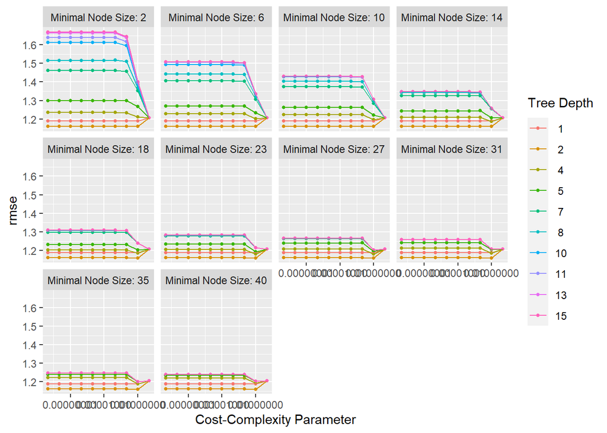

```r
#default visualization
tree_res %>% autoplot()
```

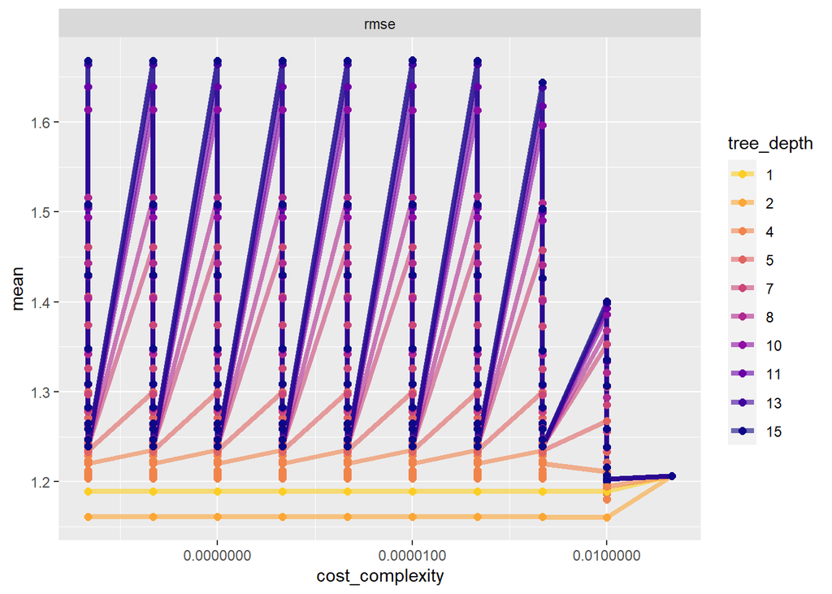

```r
#more detailed plot
tree_res %>%
  workflowsets::collect_metrics() %>%
  dplyr::mutate(tree_depth = factor(tree_depth)) %>%
  ggplot2::ggplot(aes(cost_complexity, mean, color = tree_depth)) +
           geom_line(size = 1.5, alpha = 0.6) +
           geom_point(size = 2) +
           facet_wrap(~ .metric, scales = "free", nrow = 2) +
           scale_x_log10(labels = scales::label_number()) +
           scale_color_viridis_d(option = "plasma", begin = 0.9, end = 0)
```

*5. Identify Best Model*

```r
#select the tree model with the lowest rmse
tree_lowest_rmse <- tree_res %>%
                        tune::select_best("rmse")

#finalize the workflow by using the selected lasso model
best_tree_wflow <- tree_wflow %>%
                      tune::finalize_workflow(tree_lowest_rmse)
best_tree_wflow
```

```
## == Workflow ====================================================================
## Preprocessor: Recipe
## Model: decision_tree()
##
## -- Preprocessor ----------------------------------------------------------------
## 1 Recipe Step
##
## * step_dummy()
##
## -- Model -----------------------------------------------------------------------
## Decision Tree Model Specification (regression)
##
## Main Arguments:
##   cost_complexity = 0.01
##   tree_depth = 2
##   min_n = 2
##
## Computational engine: rpart
```

```r
#one last fit on the training data
best_tree_fit <- best_tree_wflow %>%
                    parsnip::fit(data = train_data)
```

*6. Model evaluation*

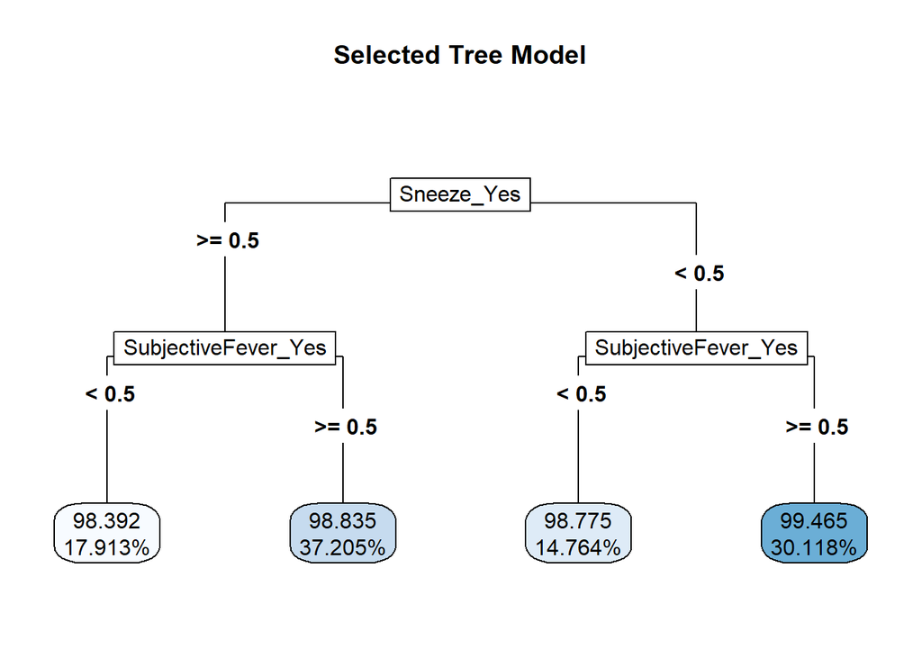

```r
#plot the tree
rpart.plot::rpart.plot(x = workflowsets::extract_fit_parsnip(best_tree_fit)$fit,
                       roundint = F,
                       type = 5,
                       digits = 5,
                       main = "Selected Tree Model")
```

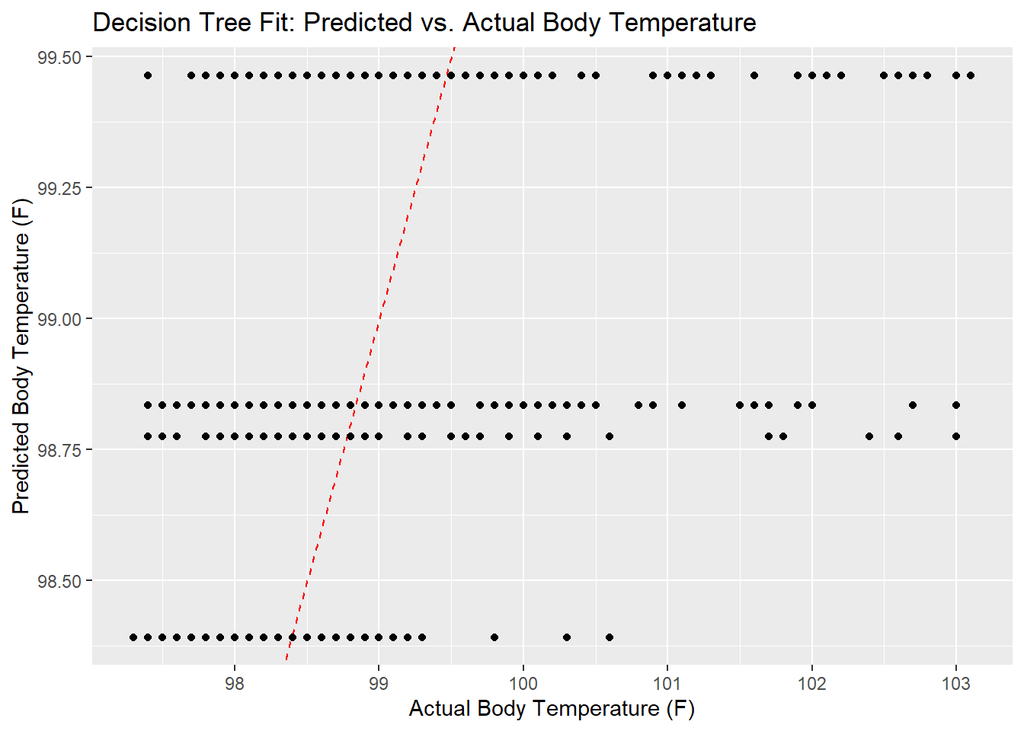

```r
#find predictions and intervals
tree_resid <- best_tree_fit %>%
                  broom.mixed::augment(new_data = train_data) %>%
                  dplyr::select(.pred, BodyTemp) %>%
                  dplyr::mutate(.resid = BodyTemp - .pred)

#plot model predictions from tuned model versus actual outcomes
#now use ggplot
ggplot2::ggplot(tree_resid, aes(x = BodyTemp, y = .pred)) +
  geom_abline(slope = 1, intercept = 0, color = "red", lty = 2) +
  geom_point() +
  labs(title = "Decision Tree Fit: Predicted vs. Actual Body Temperature",
        x = "Actual Body Temperature (F)",
        y = "Predicted Body Temperature (F)")
```

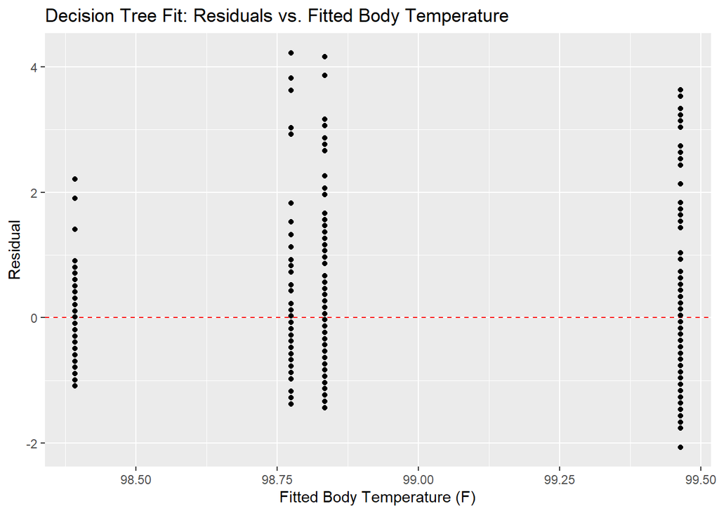

```r
#plot model with residuals
ggplot2::ggplot(tree_resid, aes(x = .pred, y = .resid))+
  geom_hline(yintercept = 0, color = "red", lty = 2) +
  geom_point() +
  labs(title = "Decision Tree Fit: Residuals vs. Fitted Body Temperature",
        x = "Fitted Body Temperature (F)",
        y = "Residual")
```

```r
#print model performance
tree_res %>%
  tune::show_best(n = 10) %>%
  dplyr::select(rmse = mean, std_err, cost_complexity) %>%
  dplyr::mutate(rmse = round(rmse, 3),
                std_err = round(std_err, 4),
                cost_complexity = scales::scientific(cost_complexity))
```

```
## # A tibble: 10 x 3
##     rmse std_err cost_complexity
##    <dbl>   <dbl> <chr>
##  1  1.16  0.0187 1e-02
##  2  1.16  0.0187 1e-02
##  3  1.16  0.0187 1e-02
##  4  1.16  0.0187 1e-02
##  5  1.16  0.0187 1e-02
##  6  1.16  0.0187 1e-02
##  7  1.16  0.0187 1e-02
##  8  1.16  0.0187 1e-02
##  9  1.16  0.0187 1e-02
## 10  1.16  0.0187 1e-02
```

```r
#this shows the 10 best performing hyperparameter sets

#compare model performance to null model
tree_RMSE <- tree_res %>%
                tune::show_best(n = 1) %>%
                dplyr::transmute(
                  rmse = round(mean, 3),
                  SE = round(std_err, 4),
                  model = "Tree") %>%
               dplyr::bind_rows(null_RMSE_train)
```

**LASSO Model** Most of the code for this section comes from the [TidyModels Tutorial Case Study](https://www.tidymodels.org/start/case-study/). *1. Model Specification*

```r
#define the lasso model
lasso_mod <-
  parsnip::linear_reg(mode = "regression",
                      penalty = tune(),
                      mixture = 1) %>%
  parsnip::set_engine("glmnet")

#use the recipe specified earlier (line 133)
```

*2. Workflow Definition*

```r
#define workflow for lasso regression
lasso_wflow <- workflows::workflow() %>%
               workflows::add_model(lasso_mod) %>%
               workflows::add_recipe(flu_rec)
```

*3. Tuning Grid Specification*

```r
#tuning grid specification
lasso_grid <- tibble(penalty = 10^seq(-3, 0, length.out = 30))

#5 lowest penalty values
lasso_grid %>%
  dplyr::top_n(-5)
```

```
## # A tibble: 5 x 1
##   penalty
##     <dbl>
## 1 0.001
## 2 0.00127
## 3 0.00161
## 4 0.00204
## 5 0.00259
```

```r
#5 highest penalty values
lasso_grid %>%
  dplyr::top_n(-5)
```

```
## # A tibble: 5 x 1
##   penalty
##     <dbl>
## 1 0.001
## 2 0.00127
## 3 0.00161
## 4 0.00204
## 5 0.00259
```

*4. Tuning Using Cross-Validation and the `tune_grid()` function*

```r
#tune the model with previously specified cross-validation and RMSE as target metric
lasso_res <- lasso_wflow %>%
                tune::tune_grid(resamples = folds,
                                grid = lasso_grid,
                                control = control_grid(verbose = TRUE, save_pred = TRUE),
                                metrics = metric_set(rmse))

#look at 15 models with lowest RMSEs
top_lasso_models <- lasso_res %>%
                      tune::show_best("rmse", n = 15) %>%
                      dplyr::arrange(penalty)
top_lasso_models
```

```
## # A tibble: 15 x 7
##    penalty .metric .estimator  mean     n std_err .config
##      <dbl> <chr>   <chr>      <dbl> <int>   <dbl> <chr>
##  1 0.00530 rmse    standard    1.17    25  0.0167 Preprocessor1_Model08
##  2 0.00672 rmse    standard    1.17    25  0.0167 Preprocessor1_Model09
##  3 0.00853 rmse    standard    1.17    25  0.0167 Preprocessor1_Model10
##  4 0.0108  rmse    standard    1.17    25  0.0167 Preprocessor1_Model11
##  5 0.0137  rmse    standard    1.16    25  0.0167 Preprocessor1_Model12
##  6 0.0174  rmse    standard    1.16    25  0.0167 Preprocessor1_Model13
##  7 0.0221  rmse    standard    1.16    25  0.0168 Preprocessor1_Model14
##  8 0.0281  rmse    standard    1.16    25  0.0169 Preprocessor1_Model15
##  9 0.0356  rmse    standard    1.15    25  0.0169 Preprocessor1_Model16
## 10 0.0452  rmse    standard    1.15    25  0.0169 Preprocessor1_Model17
## 11 0.0574  rmse    standard    1.15    25  0.0169 Preprocessor1_Model18
## 12 0.0728  rmse    standard    1.15    25  0.0170 Preprocessor1_Model19
## 13 0.0924  rmse    standard    1.16    25  0.0172 Preprocessor1_Model20
## 14 0.117   rmse    standard    1.16    25  0.0175 Preprocessor1_Model21
## 15 0.149   rmse    standard    1.17    25  0.0178 Preprocessor1_Model22
```

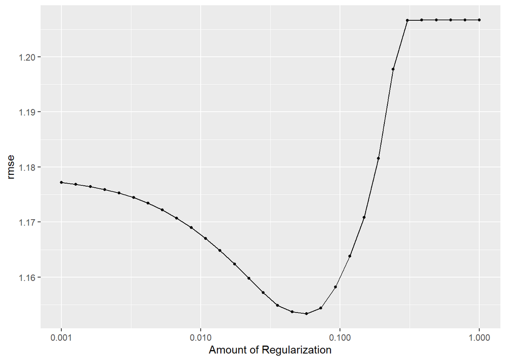

```r
#default visualization
lasso_res %>% autoplot()
```

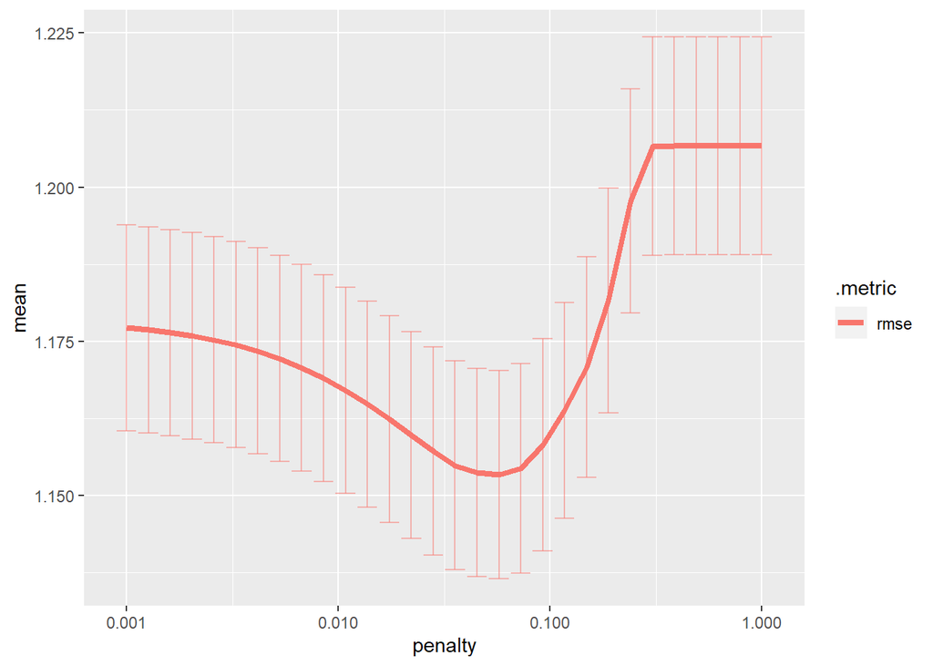

```r
#create a graph to see when there is a significant change in the penalty
lasso_res %>%
  workflowsets::collect_metrics() %>%
  ggplot2::ggplot(aes(penalty, mean, color = .metric)) +
  ggplot2::geom_errorbar(aes(ymin = mean - std_err,
                             ymax = mean + std_err),
                         alpha = 0.5) +
  ggplot2::geom_line(size = 1.5) +
  ggplot2::scale_x_log10()
```

*5. Identify Best Model*

```r
#select the lasso model with the lowest rmse
lasso_lowest_rmse <- lasso_res %>%
                        tune::select_best("rmse")

#finalize the workflow by using the selected lasso model
best_lasso_wflow <- lasso_wflow %>%
                      tune::finalize_workflow(lasso_lowest_rmse)
best_lasso_wflow
```

```
## == Workflow ====================================================================
## Preprocessor: Recipe
## Model: linear_reg()
##
## -- Preprocessor ----------------------------------------------------------------
## 1 Recipe Step
##
## * step_dummy()
##
## -- Model -----------------------------------------------------------------------
## Linear Regression Model Specification (regression)
##
## Main Arguments:
##   penalty = 0.0573615251044868
##   mixture = 1
##
## Computational engine: glmnet
```

```r
#one last fit on the training data
best_lasso_fit <- best_lasso_wflow %>%
                    parsnip::fit(data = train_data)

#create a table of model fit
lasso_tibble <- best_lasso_fit %>%
                    workflowsets::extract_fit_parsnip() %>%
                    broom::tidy() %>%
                    dplyr::mutate_if(is.numeric, round, 4)
lasso_tibble
```

```
## # A tibble: 32 x 3
##    term                  estimate penalty
##    <chr>                    <dbl>   <dbl>
##  1 (Intercept)            98.7     0.0574
##  2 SwollenLymphNodes_Yes   0       0.0574
##  3 ChestCongestion_Yes     0.0332  0.0574
##  4 ChillsSweats_Yes        0.0894  0.0574
##  5 NasalCongestion_Yes    -0.140   0.0574
##  6 Sneeze_Yes             -0.391   0.0574
##  7 Fatigue_Yes             0.178   0.0574
##  8 SubjectiveFever_Yes     0.378   0.0574
##  9 Headache_Yes            0       0.0574
## 10 Weakness_1              0.178   0.0574
## # ... with 22 more rows
```

*6. Model evaluation*

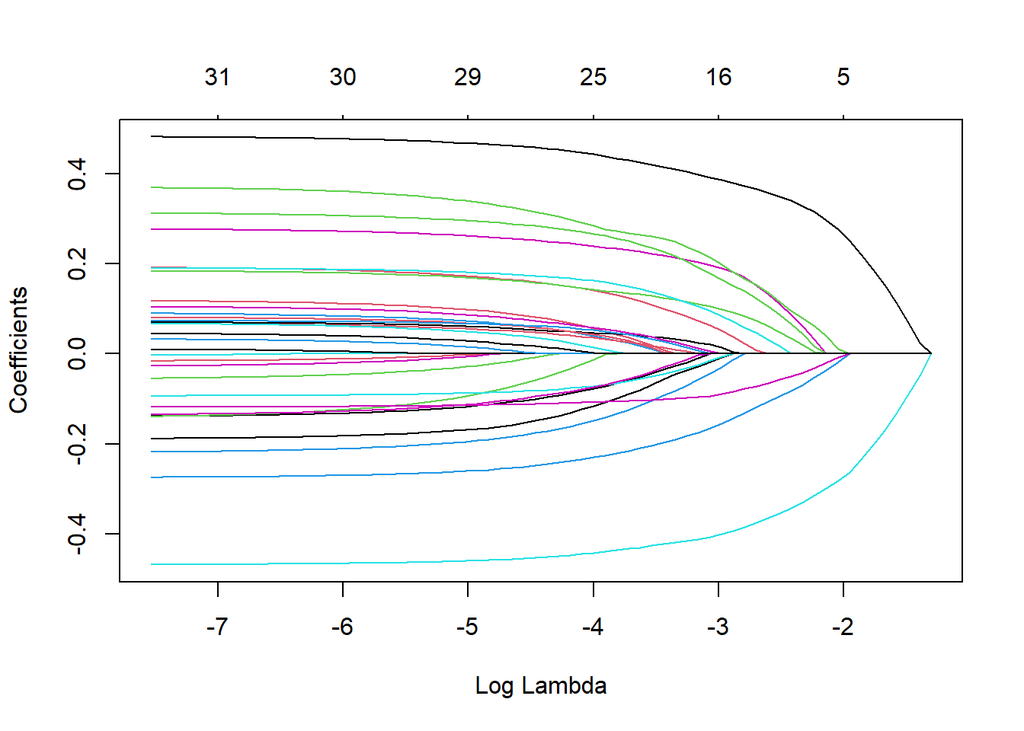

```r
#extract model from final fit
x_lasso <- best_lasso_fit$fit$fit$fit

#plot how number of predictors included in LASSO model changes with the tuning parameter
plot(x_lasso, "lambda")
```

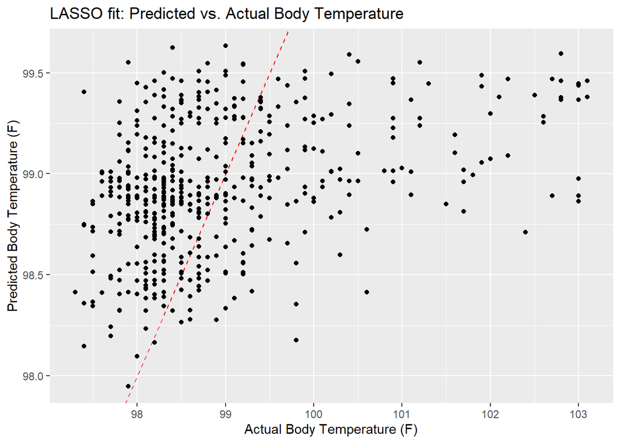

```r
#find predictions and intervals
lasso_resid <- best_lasso_fit %>%
                  broom.mixed::augment(new_data = train_data) %>%
                  dplyr::select(.pred, BodyTemp) %>%
                  dplyr::mutate(.resid = BodyTemp - .pred)

#plot model predictions from tuned model versus actual outcomes
#now use ggplot
ggplot2::ggplot(lasso_resid, aes(x = BodyTemp, y = .pred)) +
  geom_abline(slope = 1, intercept = 0, color = "red", lty = 2) +
  geom_point() +
  labs(title = "LASSO fit: Predicted vs. Actual Body Temperature",
        x = "Actual Body Temperature (F)",
        y = "Predicted Body Temperature (F)")
```

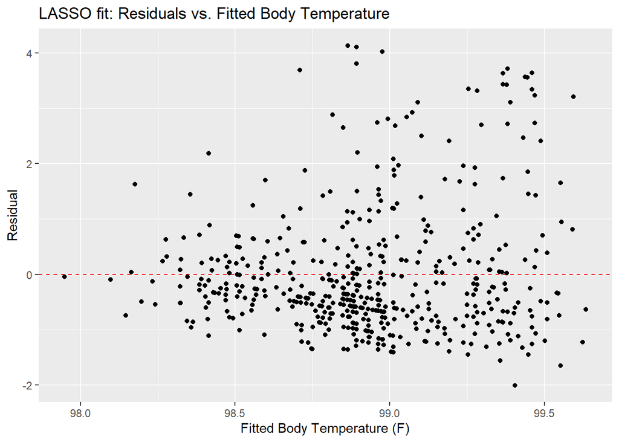

```r
#plot model with residuals
ggplot2::ggplot(lasso_resid, aes(x = .pred, y = .resid))+
  geom_hline(yintercept = 0, color = "red", lty = 2) +
  geom_point() +
  labs(title = "LASSO fit: Residuals vs. Fitted Body Temperature",
        x = "Fitted Body Temperature (F)",
        y = "Residual")
```

```r
#print model performance
lasso_res %>%
  tune::show_best(n = 10) %>%
  dplyr::select(rmse = mean, std_err, penalty) %>%
  dplyr::mutate(rmse = round(rmse, 3),
                std_err = round(std_err, 4),
                `log penalty` = round(log(penalty), 3),
                .keep = "unused")
```

```
## # A tibble: 10 x 3
##     rmse std_err `log penalty`
##    <dbl>   <dbl>         <dbl>
##  1  1.15  0.0169         -2.86
##  2  1.15  0.0169         -3.10
##  3  1.15  0.017          -2.62
##  4  1.16  0.0169         -3.34
##  5  1.16  0.0169         -3.57
##  6  1.16  0.0172         -2.38
##  7  1.16  0.0168         -3.81
##  8  1.16  0.0167         -4.05
##  9  1.16  0.0175         -2.14
## 10  1.16  0.0167         -4.29
```

```r
#this shows the 10 best performing hyperparameter sets

#compare model performance to null model
lasso_RMSE <- lasso_res %>%
                tune::show_best(n = 1) %>%
                dplyr::transmute(
                  rmse = round(mean, 3),
                  SE = round(std_err, 4),
                  model = "LASSO") %>%
               dplyr::bind_rows(tree_RMSE)
```

**Random Forest Model** Most of the code for this section comes from the [TidyModels Tutorial Case Study](https://www.tidymodels.org/start/case-study/). *1. Model Specification*

```r
#run parallels to determine number of cores
cores <- parallel::detectCores() - 1
cores
```

```
## [1] 19
```

```r
cl <- makeCluster(cores)

registerDoParallel(cl)

#define the RF model
RF_mod <-
  parsnip::rand_forest(mtry = tune(),
                       min_n = tune(),
                       trees = 1000) %>%
  parsnip::set_engine("ranger",
                      importance = "permutation") %>%
  parsnip::set_mode("regression")

#use the recipe specified earlier (line 133)

#show what will be tuned
RF_mod %>% tune::parameters()
```

```
## Collection of 2 parameters for tuning
##
##  identifier  type    object
##        mtry  mtry nparam[?]
##       min_n min_n nparam[+]
##
## Model parameters needing finalization:
##    # Randomly Selected Predictors ('mtry')
##
## See `?dials::finalize` or `?dials::update.parameters` for more information.
```

*2. Workflow Definition*

```r
#define workflow for RF regression
RF_wflow <- workflows::workflow() %>%
               workflows::add_model(RF_mod) %>%
               workflows::add_recipe(flu_rec)
```

*3. Tuning Grid Specification*

```r
#tuning grid specification
RF_grid <- expand.grid(mtry = c(3, 4, 5, 6),
                       min_n = c(40, 50, 60),
                       trees = c(500,1000))
```

*4. Tuning Using Cross-Validation and the `tune_grid()` function*

```r
#tune the model with previously specified cross-validation and RMSE as target metric
RF_res <- RF_wflow %>%
              tune::tune_grid(resamples = folds,
                              grid = 25,
                              control = control_grid(verbose = TRUE, save_pred = TRUE),
                              metrics = metric_set(rmse))
```

```
## i Creating pre-processing data to finalize unknown parameter: mtry
```

```r
#look at top 5 RF models
top_RF_models <- RF_res %>%
                    tune::show_best("rmse", n = 5)
top_RF_models
```

```
## # A tibble: 5 x 8
##    mtry min_n .metric .estimator  mean     n std_err .config
##   <int> <int> <chr>   <chr>      <dbl> <int>   <dbl> <chr>
## 1     5    38 rmse    standard    1.16    25  0.0166 Preprocessor1_Model25
## 2     5    31 rmse    standard    1.16    25  0.0167 Preprocessor1_Model17
## 3     6    27 rmse    standard    1.17    25  0.0167 Preprocessor1_Model10
## 4     2    12 rmse    standard    1.17    25  0.0169 Preprocessor1_Model03
## 5     2     8 rmse    standard    1.17    25  0.0168 Preprocessor1_Model19
```

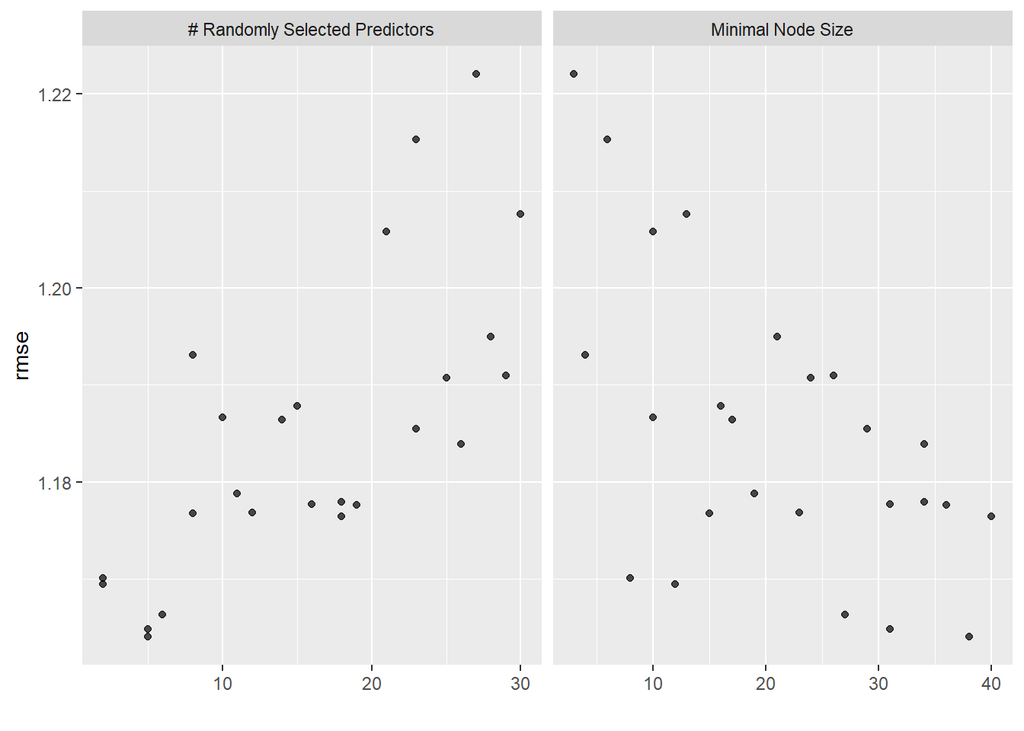

```r
#default visualization
RF_res %>% autoplot()
```

*5. Identify Best Model*

```r
#select the lasso model with the lowest rmse
RF_lowest_rmse <- RF_res %>%
                      tune::select_best("rmse")

#finalize the workflow by using the selected RF model
best_RF_wflow <- RF_wflow %>%
                      tune::finalize_workflow(RF_lowest_rmse)
best_RF_wflow
```

```
## == Workflow ====================================================================
## Preprocessor: Recipe
## Model: rand_forest()
##
## -- Preprocessor ----------------------------------------------------------------
## 1 Recipe Step
##
## * step_dummy()
##
## -- Model -----------------------------------------------------------------------
## Random Forest Model Specification (regression)
##
## Main Arguments:
##   mtry = 5
##   trees = 1000
##   min_n = 38
##
## Engine-Specific Arguments:
##   importance = permutation
##
## Computational engine: ranger
```

```r
#one last fit on the training data
best_RF_fit <- best_RF_wflow %>%
                    parsnip::fit(data = train_data)
```

*6. Model evaluation*

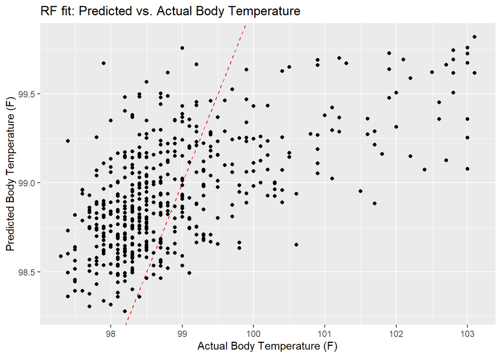

```r
#extract model from final fit
x_RF <- best_RF_fit$fit$fit$fit

#find predictions and intervals
RF_resid <- best_RF_fit %>%
                broom.mixed::augment(new_data = train_data) %>%
                dplyr::select(.pred, BodyTemp) %>%
                dplyr::mutate(.resid = BodyTemp - .pred)

#plot model predictions from tuned model versus actual outcomes
#now use ggplot
ggplot2::ggplot(RF_resid, aes(x = BodyTemp, y = .pred)) +
  geom_abline(slope = 1, intercept = 0, color = "red", lty = 2) +
  geom_point() +
  labs(title = "RF fit: Predicted vs. Actual Body Temperature",
        x = "Actual Body Temperature (F)",
        y = "Predicted Body Temperature (F)")
```

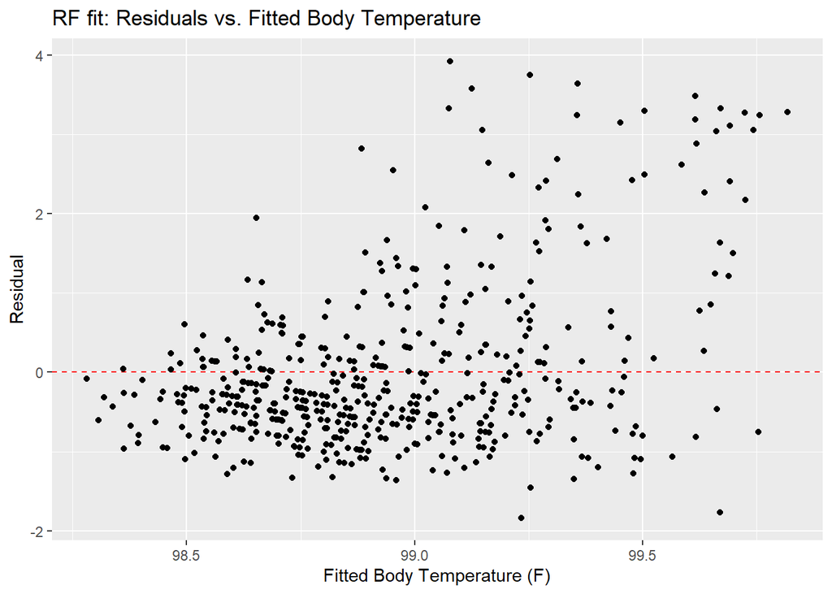

```r
#plot model with residuals
ggplot2::ggplot(RF_resid, aes(x = .pred, y = .resid))+
  geom_hline(yintercept = 0, color = "red", lty = 2) +
  geom_point() +
  labs(title = "RF fit: Residuals vs. Fitted Body Temperature",
        x = "Fitted Body Temperature (F)",
        y = "Residual")
```

```r
#print model performance
RF_res %>%
  tune::show_best(n = 10) %>%
  dplyr::select(rmse = mean, std_err) %>%
  dplyr::mutate(rmse = round(rmse, 3),
                std_err = round(std_err, 4),
                .keep = "unused")
```

```
## # A tibble: 10 x 2
##     rmse std_err
##    <dbl>   <dbl>
##  1  1.16  0.0166
##  2  1.16  0.0167
##  3  1.17  0.0167
##  4  1.17  0.0169
##  5  1.17  0.0168
##  6  1.18  0.0167
##  7  1.18  0.0165
##  8  1.18  0.0166
##  9  1.18  0.0167
## 10  1.18  0.0166
```

```r
#this shows the 10 best performing hyperparameter sets

#compare model performance to null model (and other models)
RF_RMSE <- RF_res %>%
              tune::show_best(n = 1) %>%
              dplyr::transmute(
                rmse = round(mean, 3),
                SE = round(std_err, 4),
                model = "RF") %>%
             dplyr::bind_rows(lasso_RMSE)
RF_RMSE
```

```
## # A tibble: 4 x 3
##    rmse     SE model
##   <dbl>  <dbl> <chr>
## 1  1.16 0.0166 RF
## 2  1.15 0.0169 LASSO
## 3  1.16 0.0187 Tree
## 4  1.21 0      Null - Train
```

## Model Selection and Evaluation

Based on the RMSE output above, the LASSO model has the lowest RMSE and therefore is the most appropriate model in this case. The RF and Tree models are virtually identical in their performance, but all three models are an improvement over the null model.

```r
#fit lasso model to test data
lasso_fit_test <- best_lasso_wflow %>%
                    tune::last_fit(split = data_split)

#compare test performance against training performance
lasso_rmse_test <- collect_metrics(lasso_fit_test) %>%
  dplyr::select(rmse = .estimate) %>%
  dplyr::mutate(data = "test")

lasso_RMSE %>%
  dplyr::filter(model == "LASSO") %>%
  dplyr::transmute(
    rmse, data = "train"
  ) %>%
  dplyr::bind_rows(lasso_rmse_test) %>%
  dplyr::slice(-3) #don't know why the third row shows up
```

```
## # A tibble: 2 x 2
##    rmse data
##   <dbl> <chr>
## 1  1.15 train
## 2  1.15 test
```

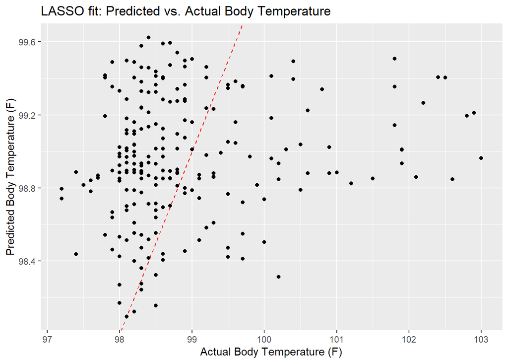

```r
#RMSEs are essentially identical --> what we want

#find predictions and intervals
lasso_resid_fit <- lasso_fit_test %>%
                  broom.mixed::augment() %>%
                  dplyr::select(.pred, BodyTemp) %>%
                  dplyr::mutate(.resid = BodyTemp - .pred)

#plot model predictions from tuned model versus actual outcomes
#now use ggplot
ggplot2::ggplot(lasso_resid_fit, aes(x = BodyTemp, y = .pred)) +
  geom_abline(slope = 1, intercept = 0, color = "red", lty = 2) +
  geom_point() +
  labs(title = "LASSO fit: Predicted vs. Actual Body Temperature",
        x = "Actual Body Temperature (F)",
        y = "Predicted Body Temperature (F)")
```

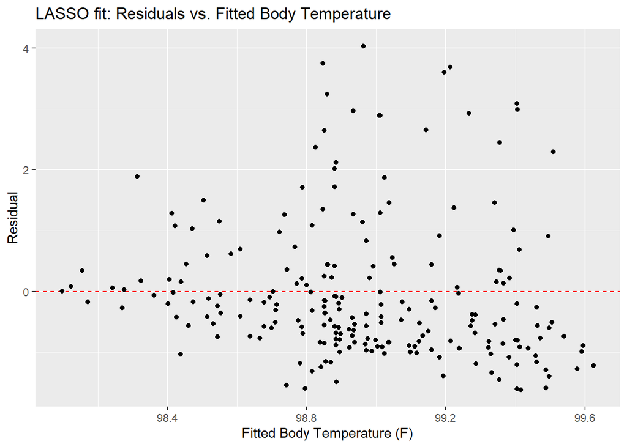

```r
#plot model with residuals
ggplot2::ggplot(lasso_resid_fit, aes(x = .pred, y = .resid))+
  geom_hline(yintercept = 0, color = "red", lty = 2) +
  geom_point() +
  labs(title = "LASSO fit: Residuals vs. Fitted Body Temperature",
        x = "Fitted Body Temperature (F)",
        y = "Residual")
```